# Suh_Assignment_5

### Intelligent SQL Assistant

## For SQL Code Generation

### Utilizing OpenAI

**Author**: Atef Bader, PhD  
**Last Edit**: 2/12/2024  
**Revised By**: Edward Arroyo, PhD

## Deliverables:

You are required to submit **three** files with the naming convention **LastName_Assignment_5** :

1. **IPYNB Script**: This is your original notebook file ( **LastName_Assignment_5.ipynb** ).
2. **HTML Document**: This file must include all the source code you have written along with its output. This should include your source code and output. Follow these steps to generate the HTML file:
   - After completing your work in the Jupyter Notebook, go to the menu bar at the top.
   - Click on File, then hover over Download as.
   - Select HTML (.html)
   - Save the file with the appropriate naming convention ( **LastName_Assignment_5.html** ).
   - **Ensure all code and outputs are properly displayed in the HTML document.**
3. **MP4 Video Recording:** A live demo recording lasting between 5 and 10 minutes.

**Note**: You are required to provide your code and its output immediately following each requirement for this assignment.

## Learning Objectives:

- Develop an **Intelligent SQL Assistant** that will :
  - Use private, personal, and real-time data (including daily tasks, calendar, diet, exercise, personal notes/documents, sports scores, etc.).
  - Be domain/goal specific (applicable to retailers, financial applications, insurance applications, etc.).
  - Make function calls to the LLM/GPT API (OpenAI) to integrate GPT's capabilities with external tools and APIs.
  - Convert natural language into API calls or database queries.
  - Answer questions posed in natural or programming languages.
  - Employ OpenAI to generate, extract, and transform text, whether natural or code-based.
  - Execute personal/business process workflows using real-time and geospatial data, for example, booking flights, ordering food, etc.
- Our **Intelligent Virtual Assistant** will differ from Apple Siri, Amazon Alexa, Google Assistant, or general internet chatbots by generating code and interacting with external tools to complete specific **tasks**.

## Learning Outcomes:

- Create an **Intelligent Virtual Assistant** capable of:
  - Using the OpenAI API to generate SQL code.
  - Employing prompt chaining for conversational AI interactions with a database server.
  - Transforming natural language queries into SQL commands.
  - Executing generated SQL queries in a chained conversation with a Database Server, such as PostgreSQL.

## Why Build/Use OpenAI Plugins, function_call, and Functions?

- The AI model acts as an intelligent API caller. It uses API specifications and a natural-language description of when to use the API to proactively perform actions. For instance, in response to a query like "Where should I stay in Paris for a couple of nights?", the model might call a hotel reservation plugin API, process the API response, and generate a comprehensive answer by integrating the API data with its natural language processing capabilities.
- ChatGPT relies on historical data, which necessitates the use of plugins/function_calls for scenarios involving:
  1. Real-time public data, such as sports scores, stock prices, and the latest news.
  2. Both real-time and non-real-time personal/private data, including company documents and personal notes.
  3. Personal/business process workflows, such as booking flights or ordering food.

## Prompt Engineering to Improve the Performance of LLMs

- This process entails refining the prompt to more effectively guide the model, which can lead to improved outcomes, particularly for complex tasks.
- Consider exploring various techniques, such as:
  - Defining the role, task, and context.
  - Using the phrase "Let’s think step by step" to direct the model towards incremental reasoning.
  - Employing few-shot learning.
- To constrain the context utilized by the OpenAI System, always start your prompt with the instruction:
  - "Do not assume, use only YOUR_KEYWORD."
- Utilize delimiters to clearly demarcate different sections of the input. Delimiters can include symbols like: `, """, < >, , and :.
- Specify your preferred output format:
  - HTML
  - JSON

### References:

Several prompt examples, utility/helper functions, and code snippets in this script have been adapted from the following sources:

- [OpenAI Platform Overview](https://platform.openai.com/docs/introduction/overview)
- [OpenAI Playground](https://platform.openai.com/playground)
- [OpenAI API Reference](https://platform.openai.com/docs/api-reference)
- [Rate Limits Overview](https://platform.openai.com/docs/guides/rate-limits/overview)
- [ChatGPT Prompt Engineering Course](https://learn.deeplearning.ai/chatgpt-prompt-eng/lesson/2/guidelines)
- [OpenAI Cookbook on GitHub](https://github.com/openai/openai-cookbook)
- Caelen, O. & Blete, M. (2023). *Developing Apps with GPT-4 and ChatGPT*. Sebastopol, CA: O’Reilly. ISBN-13: 978-1-098-15248-2

### Installing OpenAI and Other Required Packages

- Execute the command in the following cell *once* to install the necessary packages. After installation, it's recommended to comment out the code in the cell to prevent re-execution.

```python
import sys
!{sys.executable} -m pip install openai
!{sys.executable} -m pip install tenacity
!{sys.executable} -m pip install termcolor
!{sys.executable} -m pip install requests
```

```python
from openai import OpenAI
```

```python
import os
#import openai

import json
import requests
from tenacity import retry, wait_random_exponential, stop_after_attempt
from termcolor import colored

# See https://platform.openai.com/docs/models/gpt-3-5-turbo
GPT_MODEL = "gpt-3.5-turbo-1106"
```

```python
client = OpenAI(
    # Alternatively, hard code the API key like this:
    # api_key = "this is my api key"
    api_key= "",
)

chat_completion = client.chat.completions.create(
    messages=[
        {
            "role": "user",
            "content": "Say this is a test",
        }
    ],
    model = GPT_MODEL,
)
```

```python
# Helper Function

def get_completion(prompt, model=GPT_MODEL):
    messages = [{"role": "user", "content": prompt}]
    response = client.chat.completions.create(
        model=model,
        messages=messages,
        temperature=0, # this is the degree of randomness of the model's output
    )
    return response.choices[0].message.content
```

### Different Types of Output Formats:

1. List
2. Old-Style Table/Text
3. HTML
4. JSON

````python
text = f"""
what is the list of best \
electrical vehicles with mileage range and cost.
"""
prompt = f"""
Create a list \
```{text}```
"""
````

```python
message = get_completion(prompt)

print(message)
```

```
1. Tesla Model S - Mileage range: 370 miles, Cost: $79,990
2. Chevrolet Bolt EV - Mileage range: 259 miles, Cost: $36,620
3. Nissan Leaf - Mileage range: 226 miles, Cost: $31,600
4. Audi e-tron - Mileage range: 204 miles, Cost: $65,900
5. Jaguar I-PACE - Mileage range: 234 miles, Cost: $69,850
6. Hyundai Kona Electric - Mileage range: 258 miles, Cost: $37,390
7. Kia Niro EV - Mileage range: 239 miles, Cost: $39,090
8. BMW i3 - Mileage range: 153 miles, Cost: $44,450
9. Ford Mustang Mach-E - Mileage range: 300 miles, Cost: $42,895
10. Porsche Taycan - Mileage range: 227 miles, Cost: $103,800
```

```python
text = f"""
what is the list of best \
electrical vehicles with mileage range and cost.
"""
```

````python
prompt = f"""
Create a table \
```{text}```
"""
````

```python
response = get_completion(prompt)
print(response)
```

```
| Electrical Vehicle      | Mileage Range (miles) | Cost (USD) |
|-------------------------|-----------------------|------------|
| Tesla Model S           | 370                   | $79,990    |
| Chevrolet Bolt EV       | 259                   | $36,620    |
| Nissan Leaf             | 226                   | $31,600    |
| BMW i3                  | 153                   | $44,450    |
| Hyundai Kona Electric   | 258                   | $37,190    |
| Kia Niro EV             | 239                   | $39,090    |
| Audi e-tron             | 204                   | $65,900    |
| Jaguar I-PACE           | 234                   | $69,850    |
| Ford Mustang Mach-E     | 230                   | $42,895    |
| Porsche Taycan          | 192                   | $79,900    |
```

```python
from IPython.display import display, HTML
```

Create HTML Output

````python
prompt = f"""
Create HTML table \
```{text}```
"""
````

```python
response = get_completion(prompt)
display(HTML(response))
```

| Electric Vehicle | Mileage Range (miles) | Cost |
| --- | --- | --- |
| Tesla Model S | 375 | $79,990 |
| Nissan Leaf | 226 | $31,600 |
| Chevrolet Bolt EV | 259 | $36,620 |
| Tesla Model 3 | 263 | $39,990 |
| Audi e-tron | 204 | $65,900 |

Create JSON Output

````python
prompt = f"""
Create JSON  \
```{text}```
"""
````

```python
response = get_completion(prompt)
print(response)
```

```
{
  "best_electrical_vehicles": [
    {
      "name": "Tesla Model S",
      "mileage_range": "402 miles",
      "cost": "$79,990"
    },
    {
      "name": "Chevrolet Bolt EV",
      "mileage_range": "259 miles",
      "cost": "$36,620"
    },
    {
      "name": "Nissan Leaf",
      "mileage_range": "226 miles",
      "cost": "$31,600"
    },
    {
      "name": "Audi e-tron",
      "mileage_range": "222 miles",
      "cost": "$65,900"
    },
    {
      "name": "Ford Mustang Mach-E",
      "mileage_range": "305 miles",
      "cost": "$42,895"
    }
  ]
}
```

**Prompt Mini Template:**

1. Do not assume ...
2. Task ...
3. Output Format ...

```python
prompt = f"""

Do not assume, use only JSON format

Your task :
    what is the list of best electrical vehicles with mileage range and cost.


Use the following format:
    Output JSON: summary and Manufacturer, Model, mileage_range, cost


"""

response = get_completion(prompt)

print(response)
```

```
{
  "summary": "List of best electrical vehicles with mileage range and cost",
  "vehicles": [
    {
      "Manufacturer": "Tesla",
      "Model": "Model S",
      "mileage_range": "402 miles",
      "cost": "$79,990"
    },
    {
      "Manufacturer": "Chevrolet",
      "Model": "Bolt EV",
      "mileage_range": "259 miles",
      "cost": "$36,620"
    },
    {
      "Manufacturer": "Nissan",
      "Model": "Leaf",
      "mileage_range": "226 miles",
      "cost": "$31,620"
    },
    {
      "Manufacturer": "Audi",
      "Model": "e-tron",
      "mileage_range": "222 miles",
      "cost": "$65,900"
    },
    {
      "Manufacturer": "Ford",
      "Model": "Mustang Mach-E",
      "mileage_range": "305 miles",
      "cost": "$42,895"
    }
  ]
}
```

### Be Aware of OpenAI's Current Call Limit:

- RateLimitError: Rate limit reached for default-gpt-3.5-turbo in organization org-XYZ123... on requests per minute.
  - Limit: 3 / min. Please try again in 20s.

## Prompt Engineering

- An **Effective Prompt** will clearly state the following elements within the prompt body:
  1. Role
  2. Context
  3. Task
  4. Output Format

## Add Context to Your Question

```python
prompt = """
Context: I want to buy an electric vehicle.
Task: Give me a suggestion for list of vehicles to consider."""
```

```python
response = get_completion(prompt)

print(response)
```

```
Sure! Here are some popular electric vehicles to consider:

1. Tesla Model 3
2. Nissan Leaf
3. Chevrolet Bolt EV
4. BMW i3
5. Hyundai Kona Electric
6. Kia Niro EV
7. Audi e-tron
8. Ford Mustang Mach-E
9. Volkswagen ID.4
10. Porsche Taycan

These are just a few options to consider, and there are many other electric vehicles available on the market. It's important to research and test drive different models to find the best fit for your needs and preferences.
```

## Instruct the Model to Ask Questions About the Task Context

```python
prompt = """
Context: I want to buy an electric vehicle.
Task: Give me a suggestion for list of vehciles to consider.
Do not perform the requested task! Instead, can you ask me questions about the context so that when I answer, you can perform the requested task more efficiently?
"""
```

```python
response = get_completion(prompt)

print(response)
```

```
Sure! Here are some questions to help me understand your needs better:
1. What is your budget for purchasing an electric vehicle?
2. How far do you typically drive in a day or week?
3. Do you have access to charging stations at home or work?
4. Are there any specific features or requirements you have for your electric vehicle?
5. Do you have a preference for a certain brand or type of electric vehicle (e.g. sedan, SUV, etc.)?
```

## Add Details to the Task Before Asking the Model

```python
prompt = """
Context: I want to buy an electric vehicle.
Task: Give me a suggestion for list of vehciles to consider. I drive to work more than 250 miles every day, and I have a budget of $40,000 for the vehicle to buy. of

"""
```

```python
response = get_completion(prompt)

print(response)
```

```
1. Tesla Model 3 Long Range - With a range of over 300 miles, the Tesla Model 3 Long Range is a great option for your daily commute. It's within your budget and offers a luxurious driving experience.

2. Chevrolet Bolt EV - The Bolt EV has a range of over 250 miles, making it a practical choice for your long daily drives. It's also more affordable than some other electric vehicles on the market.

3. Nissan Leaf Plus - The Leaf Plus offers a range of over 200 miles and is known for its reliability and affordability. It's a great option for those looking for a practical and budget-friendly electric vehicle.

4. Hyundai Kona Electric - With a range of over 250 miles, the Kona Electric is a great choice for your daily commute. It offers a spacious interior and a smooth ride, making it a practical and comfortable option.

5. Kia Niro EV - The Niro EV offers a range of over 250 miles and is known for its practicality and value. It's a great option for those looking for a reliable and affordable electric vehicle.
```

## OpenAI Examples can be found here:

- https://platform.openai.com/examples

[figure not shown]

# Examples

### Grammar correction

- Corrects sentences to standard English.

```python
response = get_completion("Correct this to standard English: She no went to the market.")

print(response)
```

```
She did not go to the market.
```

## Python to Natural Language

- Explain a piece of Python code in a language people can understand.

```python
response = get_completion("""
# Python 3
def hello(x):
print('hello '+str(x))
# Explanation of what the code does""")

print(response)
```

```
This Python function takes a parameter x and prints "hello " followed by the value of x. The function does not return any value, it simply prints the greeting.
```

## SQL Request

- Simple SQL query building.

```python
response = get_completion("Create a SQL request to find all users who live in California and have over 1000 credits")

print(response)
```

```
SELECT *
FROM users
WHERE state = 'California'
AND credits > 1000;
```

## The Role is used to instructs the model to deliver a desired response by compelling it to reply in a manner defined by the role.

```python
prompt = """
Role: You are a salesperson for electric vehicles.
Context: I want to buy an electric vehicle.
Task: Give me a suggestion for list of vehciles to consider. I drive to work more than 250 miles every day, and I have a budget of $40,000 for the vehicle to buy. of

"""
```

```python
response = get_completion(prompt)

print(response)
```

[output not shown]

### Transformers in Large Language Models (LLMs) vs. Arithmetic Logic Units (ALUs) and Floating-Point Units (FPUs)

- Unlike ALUs and FPUs, which are hardware components designed to perform mathematical calculations, LLMs do not possess such units. In LLMs, numbers are treated similarly to words, without any specialized hardware for mathematical operations within the transformer architecture.

```python
prompt = "How much is 2+2?"

response = get_completion(prompt)

print(response)
```

```
2+2 equals 4.
```

```python
prompt = "How much is 4*5?"

response = get_completion(prompt)

print(response)
```

```
4*5 equals 20.
```

### The Answer Provided by ChatGPT for the Calculation of (123 * 456789) is Incorrect

- The correct answer is 56,185,047.

```python
prompt = "How much is 123 * 456789?"

response = get_completion(prompt)

print(response)
```

```
The product of 123 and 456789 is 56,296,547.
```

## Zero-shot Chain of Thought (CoT) Strategy

- Empirical evidence shows that adding "Let's think step by step" to the prompt enables the model to tackle more complex reasoning challenges effectively. This approach, known as the Zero-shot CoT strategy, was first detailed in the scientific paper "Large Language Models are Zero-Shot Reasoners" by Takeshi Kojima et al., published in 2022.
- Incorporating this sentence encourages the model to dissect the problem into smaller, more manageable sub-problems, thereby enhancing its reasoning capabilities. Consequently, this allows the model to deduce solutions to previously unsolvable challenges in a single attempt.
- For more information on Chain of Thought prompt runs, visit: [Chain of Thought Prompting](https://learnprompting.org/docs/intermediate/chain_of_thought).

```python
prompt = "How much is 123 * 456789? Let's think step by step."

response = get_completion(prompt)

print(response)
```

```
First, let's multiply 123 by 9:

123 * 9 = 1107

Next, let's multiply 123 by 80 and add the result to the previous step:

123 * 80 = 9840
1107 + 9840 = 10947

Finally, let's multiply 123 by 400 and add the result to the previous step:

123 * 400 = 49200
10947 + 49200 = 60147

So, 123 * 456789 = 60147.
```

## Is This Answer Correct?

### Compare the Following Three Answers Received:

- From your calculator
- From the raw prompt
- From the prompt including "Let's think step by step"

Although the model took significantly longer to provide an answer breakdown with the "Let's think step by step" prompt, giving the impression that it was dissecting the problem into sub-problems to demonstrate its logical reasoning and the mathematical calculations performed, it ultimately produced the **WRONG answer**.

## Inferring Sentiments About Products/Services Based on Their Reviews

```python
lamp_review = """
Needed a nice lamp for my bedroom, and this one had \
additional storage and not too high of a price point. \
Got it fast.  The string to our lamp broke during the \
transit and the company happily sent over a new one. \
Came within a few days as well. It was easy to put \
together.  I had a missing part, so I contacted their \
support and they very quickly got me the missing piece! \
Lumina seems to me to be a great company that cares \
about their customers and products!!
"""
```

```python
prompt = f"""
Identify the following items from the review text:
- Sentiment (positive or negative)
- Is the reviewer expressing anger? (true or false)
- Item purchased by reviewer
- Company that made the item

The review is delimited with triple backticks. \
Format your response as a JSON object with \
"Sentiment", "Anger", "Item" and "Brand" as the keys.
If the information isn't present, use "unknown" \
as the value.
Make your response as short as possible.
Format the Anger value as a boolean.

Review text: '''{lamp_review}'''
"""
response = get_completion(prompt)
print(response)
```

```
{
  "Sentiment": "positive",
  "Anger": false,
  "Item": "lamp",
  "Brand": "Lumina"
}
```

## Now that you have learned the basics of OpenAI Chat Completion, let's use it to connect to and query a relational database application.

- We will use https://api.openai.com/v1/chat/completions to send a POST request with JSON input.
- Functions and function_call will be utilized in the conversation with the database.
- Utility functions are originally provided by OpenAI Cookbook examples.

### Note that you should already created and populated the "saleco" database in the first assignment.

## Build the SaleCo Database on PostgreSQL

- Install **PostgreSQL 14** on your computer.
- Add PostgreSQL to your system's PATH environment variable: `set PATH=%PATH%;C:\Program Files\PostgreSQL\14\bin;`.
- Execute the SQL script to build the database schema and insert data into tables using **psql**: `psql -p 5433 -U postgres -f Build-DB-SaleCo.sql`.
- Use **psql** to run the following SQL scripts to establish the database schema and populate the tables:
  1. Build-DB-SaleCo.sql
  2. LoadRowsIntoDB.sql

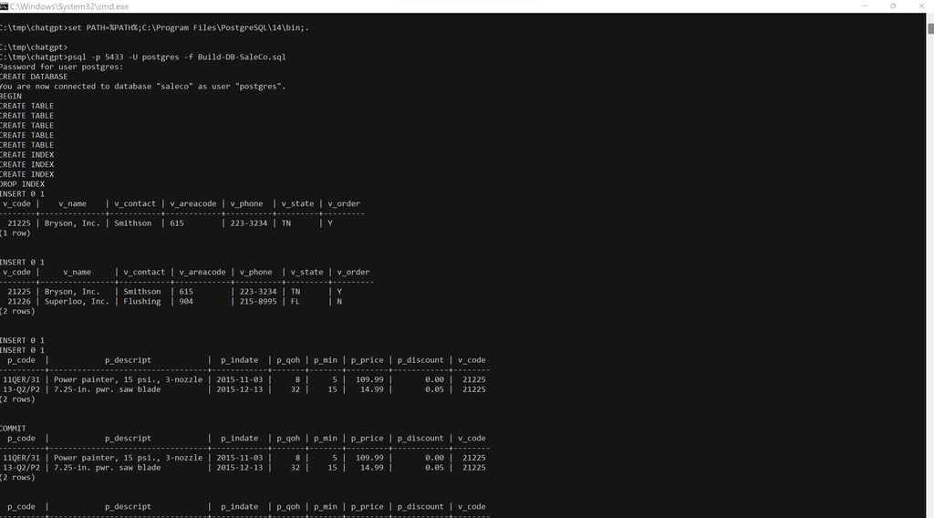

### Utilities

First let's define a few utilities for making calls to the Chat Completions API and for maintaining and keeping track of the conversation state.

```python
@retry(wait=wait_random_exponential(multiplier=1, max=40), stop=stop_after_attempt(3))
def chat_completion_request(messages, functions=None, function_call=None, model=GPT_MODEL):
    headers = {
        "Content-Type": "application/json",
        "Authorization": "Bearer " + client.api_key,
    }

    json_data = {"model": model, "messages": messages, "temperature":0.0}
    if functions is not None:
        json_data.update({"functions": functions})
    if function_call is not None:
        json_data.update({"function_call": function_call})
    try:
        response = requests.post(
            "https://api.openai.com/v1/chat/completions",
            headers=headers,
            json=json_data,
        )
        return response
    except Exception as e:
        print("Unable to generate ChatCompletion response")
        print(f"Exception: {e}")
        return e
```

```python
def pretty_print_conversation(messages):
    role_to_color = {
        "system": "red",
        "user": "green",
        "assistant": "blue",
        "function": "magenta",
    }

    for message in messages:
        if message["role"] == "system":
            print(colored(f"system: {message['content']}\n", role_to_color[message["role"]]))
        elif message["role"] == "user":
            print(colored(f"user: {message['content']}\n", role_to_color[message["role"]]))
        elif message["role"] == "assistant" and message.get("function_call"):
            print(colored(f"assistant: {message['function_call']}\n", role_to_color[message["role"]]))
        elif message["role"] == "assistant" and not message.get("function_call"):
            print(colored(f"assistant: {message['content']}\n", role_to_color[message["role"]]))
        elif message["role"] == "function":
            print(colored(f"function ({message['name']}): {message['content']}\n", role_to_color[message["role"]]))
```

```python
import psycopg2

#establishing the connection
conn = psycopg2.connect(
   database="saleco", user='postgres', password='password', host='127.0.0.1', port= '5432'
)
```

```python
#Creating a cursor object using the cursor() method
cursor = conn.cursor()

#Executing a select statement using the execute() method
cursor.execute("select version()")
```

```python
# Fetch a single row using fetchone() method.
data = cursor.fetchone()
print("Connection established to: ",data)
```

```
Connection established to:  ('PostgreSQL 17.5 (Postgres.app) on aarch64-apple-darwin23.6.0, compiled by Apple clang version 15.0.0 (clang-1500.3.9.4), 64-bit',)
```

```python
def get_table_names(conn):
    """Return a list of table names."""
    table_names = []
    cursor = conn.cursor()
    cursor.execute("SELECT table_name FROM information_schema.tables WHERE table_schema='public' AND table_type='BASE TABLE';")
    for table in cursor.fetchall():
        table_names.append(table[0])
    return table_names


def get_column_names(conn, table_name):
    """Return a list of column names."""
    column_names = []
    cursor = conn.cursor()
    cursor.execute("SELECT column_name FROM information_schema.columns WHERE table_schema = 'public' AND table_name   = %s;", [table_name])
    for col in cursor.fetchall():
        column_names.append(col[0])
    return column_names


def get_database_info(conn):
    """Return a list of dicts containing the table name and columns for each table in the database."""
    table_dicts = []
    for table_name in get_table_names(conn):
        columns_names = get_column_names(conn, table_name)
        table_dicts.append({"table_name": table_name, "column_names": columns_names})
    return table_dicts
```

```python
table_names = get_table_names(conn)
print(len(table_names), table_names)
```

```
7 ['vendor', 'product', 'customer', 'invoice', 'line', 'v', 'p']
```

```python
column_names_customer_table = get_column_names(conn, 'customer')
print(len(column_names_customer_table), column_names_customer_table)
```

```
7 ['cus_code', 'cus_lname', 'cus_fname', 'cus_initial', 'cus_areacode', 'cus_phone', 'cus_balance']
```

```python
get_database_info(conn)
```

```
[{'table_name': 'vendor',
  'column_names': ['v_code',
   'v_name',
   'v_contact',
   'v_areacode',
   'v_phone',
   'v_state',
   'v_order']},
 {'table_name': 'product',
  'column_names': ['p_code',
   'p_descript',
   'p_indate',
   'p_qoh',
   'p_min',
   'p_price',
   'p_discount',
   'v_code']},
 {'table_name': 'customer',
  'column_names': ['cus_code',
   'cus_lname',
   'cus_fname',
   'cus_initial',
   'cus_areacode',
   'cus_phone',
   'cus_balance']},
 {'table_name': 'invoice',
  'column_names': ['inv_number', 'cus_code', 'inv_date']},
 {'table_name': 'line',
  'column_names': ['inv_number',
   'line_number',
   'p_code',
   'line_units',
   'line_price']},
 {'table_name': 'v',
  'column_names': ['v_code',
   'v_name',
   'v_contact',
   'v_areacode',
   'v_phone',
   'v_state',
   'v_order']},
 {'table_name': 'p',
  'column_names': ['p_code',
   'p_descript',
   'p_indate',
   'p_qoh',
   'p_min',
   'p_price',
   'p_discount',
   'v_code']}]
```

```python
database_schema_dict = get_database_info(conn)
database_schema_string = "\n".join(
    [
        f"Table: {table['table_name']}\nColumns: {', '.join(table['column_names'])}"
        for table in database_schema_dict
    ]
)

print(database_schema_string)
```

```
Table: vendor
Columns: v_code, v_name, v_contact, v_areacode, v_phone, v_state, v_order
Table: product
Columns: p_code, p_descript, p_indate, p_qoh, p_min, p_price, p_discount, v_code
Table: customer
Columns: cus_code, cus_lname, cus_fname, cus_initial, cus_areacode, cus_phone, cus_balance
Table: invoice
Columns: inv_number, cus_code, inv_date
Table: line
Columns: inv_number, line_number, p_code, line_units, line_price
Table: v
Columns: v_code, v_name, v_contact, v_areacode, v_phone, v_state, v_order
Table: p
Columns: p_code, p_descript, p_indate, p_qoh, p_min, p_price, p_discount, v_code
```

```python
functions = [
    {
        "name": "ask_database",
        "description": "Use this function to answer user questions about saleco. Output should be a fully formed SQL query.",
        "parameters": {
            "type": "object",
            "properties": {
                "query": {
                    "type": "string",
                    "description": f"""
                            SQL query extracting info to answer the user's question.
                            SQL should be written using this database schema:
                            {database_schema_string}
                            The query should be returned in plain text, not in JSON.
                            """,
                }
            },
            "required": ["query"],
        },
    }
]
```

```python
def ask_database(conn, query):
    """Function to query Postgres database with a provided SQL query."""
    try:
        cursor = conn.cursor()
        cursor.execute(query)
        results = str(cursor.fetchall())
    except Exception as e:
        results = f"query failed with error: {e}"
    return results

def execute_function_call(message):
    if message["function_call"]["name"] == "ask_database":
        query = json.loads(message["function_call"]["arguments"])["query"]
        results = ask_database(conn, query)
    else:
        results = f"Error: function {message['function_call']['name']} does not exist"
    return results
```

## Examples: Text Descriptions to SQL Queries on `SaleCo` Database

- Hi, who are the top 3 customers by number of invoices?
- What is the name of the vendor with the most products?
- List the product names from the vendor with the most products.

```python
messages = []
messages.append({"role": "system", "content": "Answer user questions by generating SQL queries against the Saleco Database."})
messages.append({"role": "user", "content": "Hi, who are the top 3 customer by number of invoices?"})
chat_response = chat_completion_request(messages, functions)
assistant_message = chat_response.json()["choices"][0]["message"]
messages.append(assistant_message)
if assistant_message.get("function_call"):
    results = execute_function_call(assistant_message)
    messages.append({"role": "function", "name": assistant_message["function_call"]["name"], "content": results})
pretty_print_conversation(messages)
```

```
system: Answer user questions by generating SQL queries against the Saleco Database.

user: Hi, who are the top 3 customer by number of invoices?

assistant: {'name': 'ask_database', 'arguments': '{"query":"SELECT cus_code, COUNT(inv_number) AS num_invoices\\nFROM invoice\\nGROUP BY cus_code\\nORDER BY num_invoices DESC\\nLIMIT 3;"}'}

function (ask_database): [(10011, 3), (10014, 2), (10015, 1)]
```

```python
# conn.commit()
```

```python
messages.append({"role": "user", "content": "What is the name of the vendor with the most products?"})
chat_response = chat_completion_request(messages, functions)
assistant_message = chat_response.json()["choices"][0]["message"]
messages.append(assistant_message)
if assistant_message.get("function_call"):
    results = execute_function_call(assistant_message)
    messages.append({"role": "function", "content": results, "name": assistant_message["function_call"]["name"]})
pretty_print_conversation(messages)
```

```
system: Answer user questions by generating SQL queries against the Saleco Database.

user: Hi, who are the top 3 customer by number of invoices?

assistant: {'name': 'ask_database', 'arguments': '{"query":"SELECT cus_code, COUNT(inv_number) AS num_invoices\\nFROM invoice\\nGROUP BY cus_code\\nORDER BY num_invoices DESC\\nLIMIT 3;"}'}

function (ask_database): [(10011, 3), (10014, 2), (10015, 1)]

user: What is the name of the vendor with the most products?

assistant: {'name': 'ask_database', 'arguments': '{"query":"SELECT v_name, COUNT(p_code) AS num_products\\nFROM product\\nJOIN vendor ON product.v_code = vendor.v_code\\nGROUP BY vendor.v_code, v_name\\nORDER BY num_products DESC\\nLIMIT 1;"}'}

function (ask_database): [('Bryson, Inc.', 4)]
```

```python
messages.append({"role": "user", "content": "List the product names of the vendor with the most products?"})
chat_response = chat_completion_request(messages, functions)
assistant_message = chat_response.json()["choices"][0]["message"]
messages.append(assistant_message)
if assistant_message.get("function_call"):
    results = execute_function_call(assistant_message)
    messages.append({"role": "function", "content": results, "name": assistant_message["function_call"]["name"]})
pretty_print_conversation(messages)
```

[output not shown]

## Requirements

- Write your code in the cell provided below each requirement.
- The .ipynb and HTML documents you submit must include both the source code and the output for the specified requirements.

**Note**

- **Requirement 1**: For each prompt you create, use `get_completion` to obtain the response.
- **Requirement 2**: Refer to "Examples: Text Descriptions to SQL Queries on `SaleCo` Database".

**Requirement 1:** Prompt Engineering

Your task is to engineer three prompts for a business entrepreneur who plans to start an online business selling Robot Vacuum Cleaners. The prompts should provide answers to the following specifications:

- A summary of suggestions for this business startup.
- The most important features of the Robot Vacuum Cleaner that will attract customers and ensure high customer satisfaction.
- The key performance indicators (KPIs) that should be considered for the Order to Cash (O2C) process of this business.

```python
prompt = """
Role: You are a northwestern Kellog School of Business trained expert consultant.
Context: I want to start an online business sellig Robot Vacuum Cleaners
Task: Come up with three differnet stategic scenarios ranked by low to high risk and ROI profile. Provide a title and an one sentence description of key concepts.
Structure the response as strategy name:   risk/reward profile:   synopsis:

"""
response = get_completion(prompt)
print(response)
```

```
1. Market Penetration Strategy:
Risk/reward profile: Low risk, medium reward
Synopsis: This strategy focuses on capturing a larger market share by offering competitive pricing and aggressive marketing tactics to attract customers from existing competitors.

2. Product Differentiation Strategy:
Risk/reward profile: Medium risk, high reward
Synopsis: This strategy involves creating a unique selling proposition for the robot vacuum cleaners, such as advanced technology features or eco-friendly design, to stand out in the market and attract premium customers.

3. Diversification Strategy:
Risk/reward profile: High risk, potentially high reward
Synopsis: This strategy involves expanding the product line to include related home cleaning products or services, such as robot mops or subscription-based maintenance plans, to tap into new market segments and increase revenue streams.
```

```python
prompt = """
Role: You are a Harvard Business School trained expert consultant.
Context: I want to start an online business sellig Robot Vacuum Cleaners
Task: Come up with three differnet stategic scenarios ranked by low to high risk and ROI profile. Provide a title and an one sentence description of key concepts.
Structure the response as strategy name:   risk/reward profile:   synopsis:

"""
response = get_completion(prompt)
print(response)
```

```
1. Market Expansion Strategy:
Risk/reward profile: Low risk, moderate ROI
Synopsis: This strategy involves targeting new geographic markets and customer segments to increase sales and market share for robot vacuum cleaners.

2. Product Diversification Strategy:
Risk/reward profile: Moderate risk, high ROI
Synopsis: This strategy involves expanding the product line to include related home cleaning products, such as robot mops and air purifiers, to capitalize on the growing demand for smart home devices.

3. E-commerce Platform Optimization Strategy:
Risk/reward profile: High risk, potentially high ROI
Synopsis: This strategy involves investing in advanced e-commerce technology and digital marketing to enhance the online shopping experience and drive sales of robot vacuum cleaners through the company's website.
```

```python
prompt = """
Role: You are a northwestern Kellog School of Business trained expert consultant.
Context: I want to start an online business sellig Robot Vacuum Cleaners
Task: Using Product Differentiation Strategy expand a three point summary strategy to key markety differentiation to success.
keep the response to 25 words per line and maximum of 6 lines only bullet the strategy title

"""
response = get_completion(prompt)
print(response)
```

```
- High-end Technology: Offer robot vacuum cleaners with advanced sensors and mapping technology for efficient and thorough cleaning.
- Customization Options: Provide options for personalized cleaning schedules, room-specific cleaning, and customizable cleaning modes.
- Superior Customer Service: Offer exceptional customer support, extended warranties, and regular maintenance services to ensure customer satisfaction and loyalty.
```

```python
prompt = """
Role: You are a northwestern Kellog School of Business trained expert consultant.
Context: I want to start an online business sellig Robot Vacuum Cleaners
Task: what is the most important feature of vacuum cleaner that would attract most consumers in the age range and income to afford robot vacuum cleaner
keep the response to 25 words per line and maximum of 6 lines.
"""
response = get_completion(prompt)
print(response)
```

```
The most important feature for consumers in this demographic would be convenience and time-saving capabilities.
A robot vacuum cleaner that can be programmed to clean at specific times would be highly attractive.
Additionally, features such as smart navigation, app control, and voice command compatibility would also be appealing.
The ability to clean different floor types and navigate around obstacles would be a key selling point.
A long battery life and efficient cleaning performance would also be important considerations for this demographic.
Overall, a robot vacuum cleaner that offers convenience, advanced technology, and effective cleaning capabilities would be most attractive.
```

```python
prompt = """
Role: You are a northwestern Kellog School of Business trained expert consultant.
Context: I want to start an online business sellig Robot Vacuum Cleaners
Task: What are the key performance indicators (KPIs) that should be considered for the Order to Cash (O2C) process of this business.
keep the response to 25 words per line and maximum of 6 lines.
"""
response = get_completion(prompt)
print(response)
```

```
1. Order processing time
2. Order accuracy
3. Cash conversion cycle
4. DSO (Days Sales Outstanding)
5. Order fulfillment cost
6. Customer satisfaction index
```

**Requirement 2:** Use OpenAI Chat Completion to generate and execute SQL query to do the following:

List the top three most popular product names and their vendors from the SaleCo Database.

```python
messages = []
messages.append({"role": "system", "content": "Answer user questions by generating SQL queries against the Saleco Database."})
messages.append({"role": "user", "content": "List the top three most popular product names and their vendors from the SaleCo Database."})
chat_response = chat_completion_request(messages, functions)
assistant_message = chat_response.json()["choices"][0]["message"]
messages.append(assistant_message)
if assistant_message.get("function_call"):
    results = execute_function_call(assistant_message)
    messages.append({"role": "function", "name": assistant_message["function_call"]["name"], "content": results})
pretty_print_conversation(messages)
```

[output not shown]